# SOLUTIONS: Multivariable logistic regression

Adjusting for confounding in predictors of mortality after burns

GRAPH Courses team

2026-07-30

# Introduction

In week 10, we used univariable logistic regression to study predictors of mortality after burns, replicating the univariable column of Table 2 in [Kim et al. (2017)](https://doi.org/10.1371/journal.pone.0185195).

In this workshop, we go one step further and replicate the **multivariable** column, which adjusts each predictor’s association for all the other predictors.

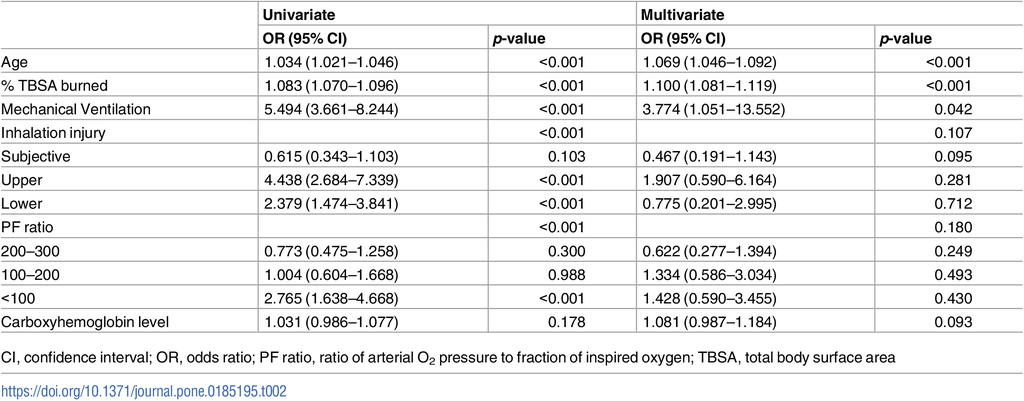

Table 2 from Kim et al. (2017).

We will model six predictors:

- Age
- Total body surface area burned (TBSA)
- Mechanical ventilation (a derived proxy; see Part 1)
- Inhalation injury
- PF ratio group
- Carboxyhemoglobin level

Along the way, we will check the model’s assumptions and compare different functional forms for age using AIC.

# PART 1: Load and prepare the data

## Load packages

First, load the packages used in this workshop. Two new additions are `performance` and `see`, which provide the `check_model()` diagnostic panel, and `patchwork`, which combines plots side by side.

```r
if (!require(pacman)) install.packages("pacman")
pacman::p_load(tidyverse, readxl, here, janitor, broom, equatiomatic, gt, patchwork, performance, see)
pacman::p_load_gh("the-graph-courses/inspectdf")
```

## Import the study data

As in week 10, we import the second sheet of the workbook and standardize its column names. This time we also keep the carboxyhemoglobin column, `CoHemo`, which is named `co_hemo` after `clean_names()`.

Fill in the missing column name below.

```r
burns_raw <- read_excel(here("data/S1Dataset_burns.xlsx"), sheet = "Sheet2") %>%
  clean_names() %>%
  select(mortaltiy, age, tbsa, ______, in_hdiv, pfdivide)

glimpse(burns_raw)
```

**Answer:**

```r
burns_raw <- read_excel(here("data/S1Dataset_burns.xlsx"), sheet = "Sheet2") %>%
  clean_names() %>%
  select(mortaltiy, age, tbsa, co_hemo, in_hdiv, pfdivide)

glimpse(burns_raw)
```

```
## Rows: 676
## Columns: 6
## $ mortaltiy <dbl> 0, 0, 0, 1, 1, 1, 0, 0, 0, 1, 0, 0, 0, 1, 1, 0, 0, 1, 0, 0, …
## $ age       <dbl> 44, 57, 59, 61, 50, 43, 52, 54, 73, 61, 45, 66, 23, 38, 65, …
## $ tbsa      <dbl> 26, 34, 36, 32, 32, 50, 39, 11, 7, 46, 8, 6, 5, 87, 62, 75, …
## $ co_hemo   <dbl> 1.4, 4.0, 1.8, 1.7, 1.4, 2.7, 3.2, 11.6, 0.8, 14.3, 2.4, 3.7…
## $ in_hdiv   <dbl> 3, 3, 3, 3, 3, 3, 3, 3, 3, 3, 3, 3, 3, 3, 3, 3, 3, 3, 3, 3, …
## $ pfdivide  <dbl> 1, 2, 1, 0, 2, 1, 3, 3, 1, 3, 2, 2, 0, 1, 3, 3, 2, 2, 3, 2, …
```

## Inspect the raw variables

Inspect the variables before changing their names, types, or labels.

[figure not shown]

```r
inspect_cat(burns_raw) %>% show_plot()
```

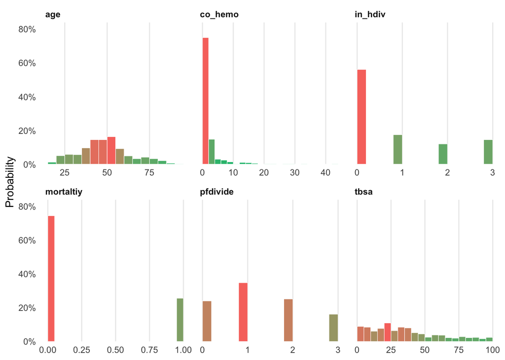

```r
inspect_num(burns_raw) %>% show_plot()
```

## Missing carboxyhemoglobin values

The carboxyhemoglobin measurement was not available for every patient. Count how many values are missing.

```r
# Count the missing values in the co_hemo column of burns_raw
sum(is.na(burns_raw$______))
```

**Answer:**

```r
sum(is.na(burns_raw$co_hemo))
```

```
## [1] 93
```

**Question 1.1:** How many patients have a missing carboxyhemoglobin value? What will happen to these patients when we fit a model that includes `co_hemo`?

Ans 1.1:

**Answer:** **93 patients** have a missing carboxyhemoglobin value. When a model includes `co_hemo`, these patients are dropped from the fit, so the model uses a **complete-case** subset of 676 - 93 = **583 patients**.

## Rename, recode, and derive variables

Now, let’s clean the variables, using the same schema as week 10:

- `mortaltiy`: 0 = Survived, 1 = Died
- `in_hdiv`: 0 = Normal, 1 = Subjective, 2 = Upper, 3 = Lower
- `pfdivide`: 0 = >300, 1 = 200-300, 2 = 100-200, 3 = <100

We also derive a new binary variable, `mech_vent`, as a **proxy** for mechanical ventilation. The dataset has no ventilation column, but the paper’s methods section tells us that patients with compromised airways who were intubated were placed in the Upper or Lower inhalation groups. We therefore approximate the ventilation group as the patients in those two groups.

Fill in the correct functions below.

```r
burns <- burns_raw %>%
  # Change the names of these columns
  ______(mortality = mortaltiy, age_years = age, tbsa_percent = tbsa) %>%
  # Change these variables to labelled factors
  ______(
    mortality = ______(mortality, levels = c(0, 1),
                       labels = c("Survived", "Died")),
    inhalation_injury = ______(in_hdiv, levels = 0:3,
                               labels = c("Normal", "Subjective", "Upper", "Lower")),
    pf_ratio_group = ______(pfdivide, levels = 0:3,
                            labels = c(">300", "200-300", "100-200", "<100")),
    # Proxy for mechanical ventilation: "Yes" for Upper/Lower, "No" otherwise.
    # Hint: the %in% operator tests whether each value is in a set.
    mech_vent = ______(inhalation_injury ______ c("Upper", "Lower"),
                       levels = c(FALSE, TRUE), labels = c("No", "Yes"))
  ) %>%
  # Keep only the variables we will use in this workshop
  ______(mortality, age_years, tbsa_percent, co_hemo,
         inhalation_injury, mech_vent, pf_ratio_group)

glimpse(burns)
```

**Answer:**

```r
burns <- burns_raw %>%
  rename(mortality = mortaltiy, age_years = age, tbsa_percent = tbsa) %>%
  mutate(
    mortality = factor(mortality, levels = c(0, 1),
                       labels = c("Survived", "Died")),
    inhalation_injury = factor(in_hdiv, levels = 0:3,
                               labels = c("Normal", "Subjective", "Upper", "Lower")),
    pf_ratio_group = factor(pfdivide, levels = 0:3,
                            labels = c(">300", "200-300", "100-200", "<100")),
    mech_vent = factor(inhalation_injury %in% c("Upper", "Lower"),
                       levels = c(FALSE, TRUE), labels = c("No", "Yes"))
  ) %>%
  select(mortality, age_years, tbsa_percent, co_hemo,
         inhalation_injury, mech_vent, pf_ratio_group)

glimpse(burns)
```

```
## Rows: 676
## Columns: 7
## $ mortality         <fct> Survived, Survived, Survived, Died, Died, Died, Surv…
## $ age_years         <dbl> 44, 57, 59, 61, 50, 43, 52, 54, 73, 61, 45, 66, 23, …
## $ tbsa_percent      <dbl> 26, 34, 36, 32, 32, 50, 39, 11, 7, 46, 8, 6, 5, 87, …
## $ co_hemo           <dbl> 1.4, 4.0, 1.8, 1.7, 1.4, 2.7, 3.2, 11.6, 0.8, 14.3, …
## $ inhalation_injury <fct> Lower, Lower, Lower, Lower, Lower, Lower, Lower, Low…
## $ mech_vent         <fct> Yes, Yes, Yes, Yes, Yes, Yes, Yes, Yes, Yes, Yes, Ye…
## $ pf_ratio_group    <fct> 200-300, 100-200, 200-300, >300, 100-200, 200-300, <…
```

**Question 1.2:** Our proxy treats every Upper or Lower patient as “ventilated” and every Normal or Subjective patient as “not ventilated”. In the paper, mechanical ventilation was actually performed in 48 of 81 Upper patients (59.3%) and 84 of 98 Lower patients (85.7%). What does this tell you about the quality of our proxy?

Ans 1.2:

**Answer:** The proxy is imperfect. It counts some patients who were not ventilated as ventilated (about 40% of the Upper group and 14% of the Lower group), so it really measures something closer to **intubation or airway-injury severity** than ventilation itself. This misclassification means results for the proxy will not match the paper’s ventilation rows exactly.

The cross-tabulation below confirms that our derived variable is an exact function of the inhalation groups.

```r
burns %>% tabyl(inhalation_injury, mech_vent)
```

```
##  inhalation_injury  No Yes
##             Normal 379   0
##         Subjective 118   0
##              Upper   0  81
##              Lower   0  98
```

**Question 1.3:** Because `mech_vent` is derived entirely from `inhalation_injury`, the two variables cannot enter the same regression model. In your own words, why not?

Ans 1.3:

**Answer:** `mech_vent` is a perfect function of `inhalation_injury`: it is “Yes” exactly when inhalation injury is Upper or Lower. Its information is therefore already fully contained in the inhalation dummy variables, so the model has **perfect collinearity** and cannot estimate a separate effect for each. R will silently drop one of the terms (we see this in Part 3).

## Outcome summary

As a reminder, here is the outcome distribution.

```r
burns %>% tabyl(mortality)
```

```
##  mortality   n   percent
##   Survived 503 0.7440828
##       Died 173 0.2559172
```

# PART 2: Univariable models for all six predictors

In week 10 you wrote univariable models yourself, so this week the code is provided for you. Read each section, run the chunks, and focus on interpretation.

We fit one model per predictor:

```r
age_model        <- glm(mortality ~ age_years, family = binomial, data = burns)
tbsa_model       <- glm(mortality ~ tbsa_percent, family = binomial, data = burns)
mech_vent_model  <- glm(mortality ~ mech_vent, family = binomial, data = burns)
inhalation_model <- glm(mortality ~ inhalation_injury, family = binomial, data = burns)
pf_group_model   <- glm(mortality ~ pf_ratio_group, family = binomial, data = burns)
co_hemo_model    <- glm(mortality ~ co_hemo, family = binomial, data = burns)
```

And we extract odds ratios with confidence intervals:

```r
age_results        <- tidy(age_model, conf.int = TRUE, exponentiate = TRUE)
tbsa_results       <- tidy(tbsa_model, conf.int = TRUE, exponentiate = TRUE)
mech_vent_results  <- tidy(mech_vent_model, conf.int = TRUE, exponentiate = TRUE)
inhalation_results <- tidy(inhalation_model, conf.int = TRUE, exponentiate = TRUE)
pf_results         <- tidy(pf_group_model, conf.int = TRUE, exponentiate = TRUE)
co_hemo_results    <- tidy(co_hemo_model, conf.int = TRUE, exponentiate = TRUE)
```

The formatting code below combines all six models into one table, matching the order of the paper’s Table 2. All formatting code is provided; as always, check the formatted values against model output that you understand.

```r
uni_model_results <- bind_rows(
  "Age" = age_results,
  "TBSA burned" = tbsa_results,
  "Mechanical ventilation (proxy)" = mech_vent_results,
  "Inhalation injury" = inhalation_results,
  "PF ratio" = pf_results,
  "Carboxyhemoglobin" = co_hemo_results,
  .id = "predictor"
) %>%
  filter(term != "(Intercept)") %>%
  transmute(
    predictor,
    comparison = recode(
      term,
      age_years = "Per 1-year increase",
      tbsa_percent = "Per 1-percentage-point increase",
      mech_ventYes = "Yes vs No",
      inhalation_injurySubjective = "Subjective vs Normal",
      inhalation_injuryUpper = "Upper vs Normal",
      inhalation_injuryLower = "Lower vs Normal",
      `pf_ratio_group200-300` = "200-300 vs >300",
      `pf_ratio_group100-200` = "100-200 vs >300",
      `pf_ratio_group<100` = "<100 vs >300",
      co_hemo = "Per 1-percentage-point increase"
    ),
    OR = estimate,
    conf_low = conf.low,
    conf_high = conf.high,
    p_value = p.value
  )

uni_reference_rows <- tribble(
  ~predictor,                         ~comparison,          ~OR, ~conf_low, ~conf_high, ~p_value,
  "Mechanical ventilation (proxy)",   "No (reference)",       1,   NA_real_,   NA_real_, NA_real_,
  "Inhalation injury",                "Normal (reference)",   1,   NA_real_,   NA_real_, NA_real_,
  "PF ratio",                         ">300 (reference)",     1,   NA_real_,   NA_real_, NA_real_
)

uni_all_results <- bind_rows(uni_model_results, uni_reference_rows) %>%
  mutate(
    predictor = factor(
      predictor,
      levels = c("Age", "TBSA burned", "Mechanical ventilation (proxy)",
                 "Inhalation injury", "PF ratio", "Carboxyhemoglobin")
    ),
    is_reference = str_detect(comparison, "reference"),
    `95% CI` = if_else(
      is_reference,
      "Reference",
      sprintf("%.3f to %.3f", conf_low, conf_high)
    ),
    p_value = if_else(
      is.na(p_value),
      "",
      scales::pvalue(p_value, accuracy = 0.001)
    )
  ) %>%
  arrange(predictor, desc(is_reference)) %>%
  select(predictor, comparison, OR, `95% CI`, p_value)

uni_all_results %>%
  gt(groupname_col = "predictor") %>%
  cols_label(
    comparison = "Comparison",
    OR = "OR",
    `95% CI` = "95% CI",
    p_value = "p-value"
  ) %>%
  fmt_number(columns = OR, decimals = 3) %>%
  cols_align(align = "center", columns = c(OR, `95% CI`, p_value)) %>%
  tab_header(title = md("**Univariable logistic regression results**"))
```

**Univariable logistic regression results**

| Comparison | OR | 95% CI | p-value |
| --- | --- | --- | --- |
| Age |  |  |  |
| Per 1-year increase | 1.034 | 1.021 to 1.046 | <0.001 |
| TBSA burned |  |  |  |
| Per 1-percentage-point increase | 1.083 | 1.070 to 1.096 | <0.001 |
| Mechanical ventilation (proxy) |  |  |  |
| No (reference) | 1.000 | Reference |  |
| Yes vs No | 3.510 | 2.424 to 5.094 | <0.001 |
| Inhalation injury |  |  |  |
| Normal (reference) | 1.000 | Reference |  |
| Subjective vs Normal | 0.615 | 0.333 to 1.077 | 0.103 |
| Upper vs Normal | 4.438 | 2.689 to 7.370 | <0.001 |
| Lower vs Normal | 2.379 | 1.467 to 3.832 | <0.001 |
| PF ratio |  |  |  |
| >300 (reference) | 1.000 | Reference |  |
| 200-300 vs >300 | 0.773 | 0.475 to 1.262 | 0.300 |
| 100-200 vs >300 | 1.004 | 0.604 to 1.671 | 0.988 |
| <100 vs >300 | 2.765 | 1.644 to 4.694 | <0.001 |
| Carboxyhemoglobin |  |  |  |
| Per 1-percentage-point increase | 1.031 | 0.985 to 1.077 | 0.178 |

**Question 2.1:** Write a full interpretation of the carboxyhemoglobin row. Include the OR, what one “unit” means here, whether the 95% CI crosses 1, and statistical significance. Compare with the paper’s univariable result of OR 1.031 (95% CI 0.986 to 1.077, p = 0.178).

Ans 2.1:

**Answer:** Each additional percentage point of carboxyhemoglobin was associated with about **1.031 times the odds** of mortality (about 3.1% higher odds). The 95% CI (0.985 to 1.077) **crosses 1**, and the p-value is 0.178, so the result is **not statistically significant**. This matches the paper’s univariable estimate almost exactly (OR 1.031, 95% CI 0.986 to 1.077, p = 0.178).

**Question 2.2:** Our ventilation proxy has OR 3.510 (95% CI 2.424 to 5.094), while the paper’s measured ventilation variable had OR 5.494 (95% CI 3.661 to 8.244). Both point in the same direction, but ours is weaker. Suggest one reason why a proxy might produce a smaller odds ratio than the true measured variable.

Ans 2.2:

**Answer:** The proxy **misclassifies** some patients: some intubated patients who were never ventilated are counted as ventilated. This kind of misclassification usually **dilutes** the association, pulling the odds ratio toward 1, so the proxy’s estimate is weaker than the estimate from the truly measured variable.

**Question 2.3:** Looking at the combined table, which predictors were statistically significant in the univariable models?

Ans 2.3:

**Answer:** Age, TBSA burned, the ventilation proxy, Upper and Lower inhalation injury (vs Normal), and PF ratio <100 (vs >300) were significant. Subjective inhalation injury, PF ratio 200-300 and 100-200, and carboxyhemoglobin were not. This agrees with the paper’s univariable findings.

# PART 3: Multivariable logistic regression

A univariable model estimates each predictor’s **crude** association with the outcome. That association may be **confounded**: for example, older patients may also have larger burns, so part of age’s univariable association could actually reflect TBSA.

A multivariable model estimates each predictor’s association while **holding the other predictors constant**. We say the estimates are “adjusted for” the other predictors.

## The multivariable equation

For our five-predictor model, the equation on the log-odds scale has one intercept and one coefficient per comparison:

> log-odds(mortality) = β₀ + β₁(age) + β₂(TBSA) + β₃(Subjective) + β₄(______) + β₅(______) + β₆(PF 200-300) + β₇(______) + β₈(PF <100) + β₉(______)

**Question 3.1:** Fill in the four blanks in the equation above.

Ans 3.1:

**Answer:** The blanks are β₄(**Upper**), β₅(**Lower**), β₇(**PF 100-200**), and β₉(**carboxyhemoglobin**):

> log-odds(mortality) = β₀ + β₁(age) + β₂(TBSA) + β₃(Subjective) + β₄(Upper) + β₅(Lower) + β₆(PF 200-300) + β₇(PF 100-200) + β₈(PF <100) + β₉(carboxyhemoglobin)

**Question 3.2:** In this equation, what does exp(β₄) represent? And why are there no terms for “Normal” inhalation status or PF ratio “>300”?

Ans 3.2:

**Answer:** exp(β₄) is the **adjusted odds ratio** comparing the Upper inhalation group with the Normal group, holding all other predictors constant. Normal and >300 are the **reference categories**: their log-odds are absorbed into the intercept β₀, so they need no separate terms. All the β₃ to β₈ coefficients are comparisons with these reference groups.

## Fit the multivariable model

Now fit the model yourself. Use all five predictors: exact age, exact TBSA, the four-level inhalation injury factor, the four-level PF ratio factor, and exact carboxyhemoglobin.

```r
# Outcome: mortality. Five predictors, separated by + signs.
mv_model <- glm(mortality ~ ______ + ______ + ______ + ______ + ______,
                family = ______, data = ______)
summary(mv_model)
```

**Answer:**

```r
mv_model <- glm(mortality ~ age_years + tbsa_percent + inhalation_injury +
                  pf_ratio_group + co_hemo,
                family = binomial, data = burns)
summary(mv_model)
```

```
##
## Call:
## glm(formula = mortality ~ age_years + tbsa_percent + inhalation_injury +
##     pf_ratio_group + co_hemo, family = binomial, data = burns)
##
## Coefficients:
##                             Estimate Std. Error z value Pr(>|z|)
## (Intercept)                 -9.18640    0.91662 -10.022  < 2e-16 ***
## age_years                    0.06561    0.01075   6.102 1.05e-09 ***
## tbsa_percent                 0.09530    0.00858  11.108  < 2e-16 ***
## inhalation_injurySubjective -0.77781    0.45768  -1.699  0.08924 .
## inhalation_injuryUpper       1.38447    0.45878   3.018  0.00255 **
## inhalation_injuryLower       0.86237    0.39510   2.183  0.02906 *
## pf_ratio_group200-300       -0.45487    0.40900  -1.112  0.26608
## pf_ratio_group100-200        0.27732    0.41560   0.667  0.50459
## pf_ratio_group<100           0.43654    0.44668   0.977  0.32843
## co_hemo                      0.08897    0.04466   1.992  0.04635 *
## ---
## Signif. codes:  0 '***' 0.001 '**' 0.01 '*' 0.05 '.' 0.1 ' ' 1
##
## (Dispersion parameter for binomial family taken to be 1)
##
##     Null deviance: 677.26  on 582  degrees of freedom
## Residual deviance: 305.17  on 573  degrees of freedom
##   (93 observations deleted due to missingness)
## AIC: 325.17
##
## Number of Fisher Scoring iterations: 6
```

**Question 3.3:** The output notes that some observations were “deleted due to missingness”. How many patients does this model use, and why is it fewer than 676?

Ans 3.3:

**Answer:** The model uses **583 patients**. The 93 patients with a missing carboxyhemoglobin value are dropped, because a model can only use rows with complete data on all included predictors (complete-case analysis). This is worth flagging as a limitation when reporting.

## The fitted equation and adjusted odds ratios

Display the fitted equation.

```r
# Model object: mv_model.
extract_eq(______, use_coefs = TRUE) %>% preview_eq()
```

**Answer:**

```r
extract_eq(mv_model, use_coefs = TRUE) %>% preview_eq()
```

Now display the adjusted odds ratios with confidence intervals.

```r
# Model: mv_model. Request confidence intervals and exponentiated estimates.
mv_results <- tidy(______, conf.int = ______, exponentiate = ______)
mv_results
```

**Answer:**

```r
mv_results <- tidy(mv_model, conf.int = TRUE, exponentiate = TRUE)
mv_results
```

```
## # A tibble: 10 × 7
##    term                 estimate std.error statistic  p.value conf.low conf.high
##    <chr>                   <dbl>     <dbl>     <dbl>    <dbl>    <dbl>     <dbl>
##  1 (Intercept)          0.000102   0.917     -10.0   1.22e-23  1.51e-5  0.000555
##  2 age_years            1.07       0.0108      6.10  1.05e- 9  1.05e+0  1.09
##  3 tbsa_percent         1.10       0.00858    11.1   1.15e-28  1.08e+0  1.12
##  4 inhalation_injurySu… 0.459      0.458      -1.70  8.92e- 2  1.81e-1  1.10
##  5 inhalation_injuryUp… 3.99       0.459       3.02  2.55e- 3  1.63e+0  9.95
##  6 inhalation_injuryLo… 2.37       0.395       2.18  2.91e- 2  1.09e+0  5.16
##  7 pf_ratio_group200-3… 0.635      0.409      -1.11  2.66e- 1  2.83e-1  1.41
##  8 pf_ratio_group100-2… 1.32       0.416       0.667 5.05e- 1  5.86e-1  3.00
##  9 pf_ratio_group<100   1.55       0.447       0.977 3.28e- 1  6.45e-1  3.74
## 10 co_hemo              1.09       0.0447      1.99  4.63e- 2  9.95e-1  1.18
```

**Question 3.4:** Write one sentence interpreting the adjusted age odds ratio (OR 1.068, 95% CI 1.046 to 1.091). How does it compare with the univariable estimate of 1.034?

Ans 3.4:

**Answer:** Holding TBSA burned, inhalation injury, PF ratio group, and carboxyhemoglobin constant, each additional year of age was associated with about **1.068 times the odds** of mortality (about **6.8% higher odds** per year). This is **stronger** than the univariable estimate of 1.034, so the other predictors were masking part of age’s association.

**Question 3.5:** In our multivariable model, the Upper inhalation group has OR 3.993 (95% CI 1.635 to 9.945, p = 0.003). In the paper’s multivariable model, which also adjusted for measured mechanical ventilation, the same group had OR 1.907 (95% CI 0.590 to 6.164, p = 0.281). What does this comparison suggest about why the Upper group’s univariable association was so strong?

Ans 3.5:

**Answer:** When the paper additionally adjusted for mechanical ventilation, the Upper group’s odds ratio dropped toward 1 and became non-significant. This suggests that much of the Upper group’s strong apparent association operates **through** ventilation (ventilation confounds or mediates the inhalation association). Our model cannot reproduce this directly, because we lack a measured ventilation variable and our derived proxy cannot enter the same model as the inhalation groups.

**Question 3.6:** PF ratio <100 was a significant predictor in the univariable model (OR 2.765, p < 0.001) but not in the multivariable model (OR 1.547, p = 0.329). What does this change suggest?

Ans 3.6:

**Answer:** The univariable association of PF ratio <100 with mortality appears to be largely **explained by the other predictors**: sicker patients with low PF ratios also tend to be older, have larger burns, and have inhalation injuries. After adjusting for these, the odds ratio moved toward 1 and became non-significant, consistent with confounding rather than an independent effect. The paper found the same pattern.

## Calculate a fitted probability by hand

Let’s calculate the estimated mortality probability for one specific patient:

- 50 years old
- 30% TBSA burned
- Upper inhalation injury
- PF ratio >300 (the reference group, so no PF term is added)
- Carboxyhemoglobin of 2%

From the model summary, the relevant coefficients are approximately: intercept -9.1864, age 0.0656, TBSA 0.0953, Upper 1.3845, carboxyhemoglobin 0.0890.

Fill in the blanks to build up this patient’s fitted log-odds.

```r
patient_log_odds <- -9.1864 + (0.0656 * ______) + (0.0953 * ______) + ______ + (0.0890 * ______)

patient_probability <- 1 / (1 + exp(-patient_log_odds))
patient_probability
```

**Answer:**

```r
patient_log_odds <- -9.1864 + (0.0656 * 50) + (0.0953 * 30) + 1.3845 + (0.0890 * 2)

patient_probability <- 1 / (1 + exp(-patient_log_odds))
patient_probability
```

```
## [1] 0.1846884
```

We can verify the calculation with `predict()`. All of this code is provided.

```r
new_patient <- tibble(
  age_years = 50,
  tbsa_percent = 30,
  inhalation_injury = "Upper",
  pf_ratio_group = ">300",
  co_hemo = 2
)

predict(mv_model, newdata = new_patient, type = "response")
```

```
##         1
## 0.1847498
```

**Question 3.7:** Does the hand-calculated probability match the result from `predict()`? What is this patient’s estimated mortality probability, as a percentage?

Ans 3.7:

**Answer:** Yes, both give approximately **0.185**, or **18.5%**. The unrounded values differ very slightly because the hand calculation uses rounded coefficients.

## Adding the ventilation proxy: a collinearity problem

The paper’s multivariable model included mechanical ventilation alongside the inhalation groups. We might be tempted to do the same with our proxy. Run the provided demonstration below.

```r
demo_both <- glm(mortality ~ age_years + tbsa_percent + inhalation_injury + mech_vent +
                   pf_ratio_group + co_hemo,
                 family = binomial, data = burns)

coef(demo_both)
```

```
##                 (Intercept)                   age_years
##                 -9.18640389                  0.06560865
##                tbsa_percent inhalation_injurySubjective
##                  0.09530234                 -0.77781000
##      inhalation_injuryUpper      inhalation_injuryLower
##                  1.38447138                  0.86237326
##                mech_ventYes       pf_ratio_group200-300
##                          NA                 -0.45486878
##       pf_ratio_group100-200          pf_ratio_group<100
##                  0.27732086                  0.43653547
##                     co_hemo
##                  0.08896873
```

**Question 3.8:** What happened to the `mech_ventYes` coefficient, and why?

Ans 3.8:

**Answer:** The `mech_ventYes` coefficient is `NA`: R silently **dropped** it. Because `mech_vent` is “Yes” exactly when inhalation injury is Upper or Lower, its dummy is a perfect sum of the Upper and Lower dummies. With **perfect collinearity**, no separate coefficient can be estimated.

Since we cannot include both variables, one option is to **swap** them: replace the four-level inhalation factor with the two-level ventilation proxy. This also parallels the paper’s headline finding that mechanical ventilation is a key risk factor.

Fit this swapped model yourself.

```r
# Replace inhalation_injury with the mech_vent proxy. Keep the other four predictors.
mv_vent_model <- glm(mortality ~ age_years + tbsa_percent + ______ + pf_ratio_group + co_hemo,
                     family = ______, data = burns)

mv_vent_results <- tidy(______, conf.int = TRUE, exponentiate = ______)
mv_vent_results
```

**Answer:**

```r
mv_vent_model <- glm(mortality ~ age_years + tbsa_percent + mech_vent +
                       pf_ratio_group + co_hemo,
                     family = binomial, data = burns)

mv_vent_results <- tidy(mv_vent_model, conf.int = TRUE, exponentiate = TRUE)
mv_vent_results
```

```
## # A tibble: 8 × 7
##   term                  estimate std.error statistic  p.value conf.low conf.high
##   <chr>                    <dbl>     <dbl>     <dbl>    <dbl>    <dbl>     <dbl>
## 1 (Intercept)            8.07e-5   0.916     -10.3   7.49e-25  1.19e-5  0.000436
## 2 age_years              1.07e+0   0.0107      6.26  3.83e-10  1.05e+0  1.09
## 3 tbsa_percent           1.10e+0   0.00857    11.1   1.22e-28  1.08e+0  1.12
## 4 mech_ventYes           3.48e+0   0.323       3.86  1.12e- 4  1.86e+0  6.62
## 5 pf_ratio_group200-300  6.62e-1   0.404      -1.02  3.08e- 1  2.98e-1  1.46
## 6 pf_ratio_group100-200  1.35e+0   0.414       0.725 4.69e- 1  6.01e-1  3.06
## 7 pf_ratio_group<100     1.51e+0   0.436       0.944 3.45e- 1  6.42e-1  3.57
## 8 co_hemo                1.08e+0   0.0445      1.81  7.03e- 2  9.87e-1  1.17
```

**Question 3.9:** Interpret the ventilation row of the swapped model. How does it compare with the paper’s multivariable estimate of OR 3.774 (95% CI 1.051 to 13.552, p = 0.042)?

Ans 3.9:

**Answer:** Holding the other predictors constant, patients in the ventilation proxy group had about **3.478 times the odds** of mortality (95% CI 1.861 to 6.623, p < 0.001). This matches the paper’s conclusion that ventilation is a strong independent risk factor (OR 3.774, p = 0.042), although our proxy’s point estimate is somewhat smaller and its confidence interval narrower.

Finally, compare the fit of our two multivariable models with AIC. Recall from the pre-work that AIC = residual deviance + 2k, where k is the number of estimated parameters, and that AIC can only be compared between models fitted to the same outcome and the same rows.

```r
# Pass the two multivariable model objects to AIC()
AIC(______, ______)
```

**Answer:**

```r
AIC(mv_model, mv_vent_model)
```

```
##               df      AIC
## mv_model      10 325.1698
## mv_vent_model  8 325.2461
```

**Question 3.10:** The two models have almost identical AIC values (within 0.1 of each other), but the ventilation-swap model uses two fewer parameters. What does this tell you about the information carried by the ventilation proxy and the four-level inhalation variable?

Ans 3.10:

**Answer:** The nearly identical AICs mean the two parameterizations carry almost the **same explanatory information**: the ventilation proxy is essentially a compressed version of the inhalation groups (it collapses Upper and Lower into one level). The swap model achieves the same fit with fewer parameters, so it is slightly more parsimonious, but neither model is clearly “better” on statistical grounds. The choice should be guided by the clinical question and by which variable is more meaningful to report.

# PART 4: Model assumption checks

In week 9 you used the SUNSHINE checklist for **linear** regression. Many of the same ideas apply to logistic regression, with a few important differences.

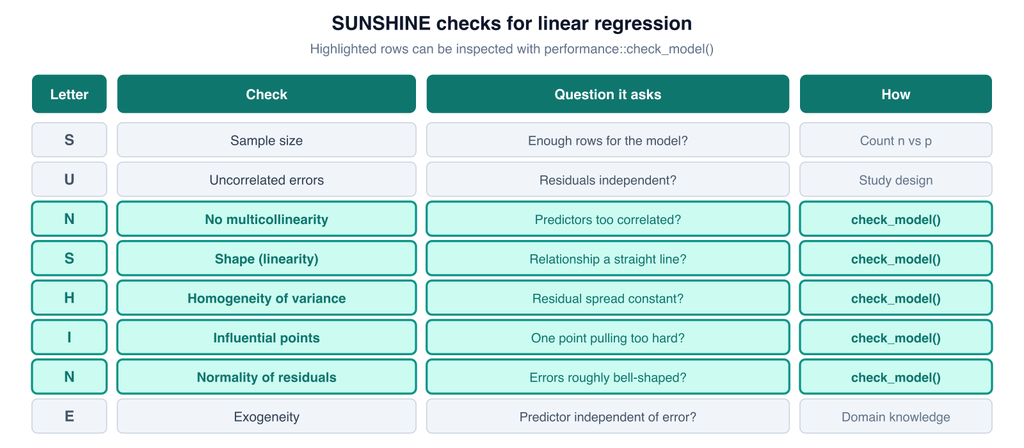

Here is how each letter translates to a logistic model:

[output not shown]

## Sample size check

The code below counts the events among the complete-case rows and divides by the number of estimated parameters.

```r
burns_complete <- burns[complete.cases(burns), ]

events <- sum(burns_complete$mortality == "Died")
n_parameters <- length(coef(mv_model))

events / n_parameters
```

```
## [1] 15.6
```

**Question 4.1:** How many parameters does `mv_model` estimate (including the intercept)?

Ans 4.1:

**Answer:** **10 parameters**: one intercept, one coefficient each for age, TBSA, and carboxyhemoglobin, three dummy coefficients for inhalation injury, and three for PF ratio group.

**Question 4.2:** Based on the guideline of at least 10 events per parameter, do we have enough events for this model?

Ans 4.2:

**Answer:** Yes. There are **156 deaths** among the 583 complete-case patients, giving 156 / 10 = **15.6 events per parameter**, comfortably above the rule-of-thumb minimum of 10.

## Run `check_model()`

Now, let’s run the full diagnostic panel for the checks that can be performed visually.

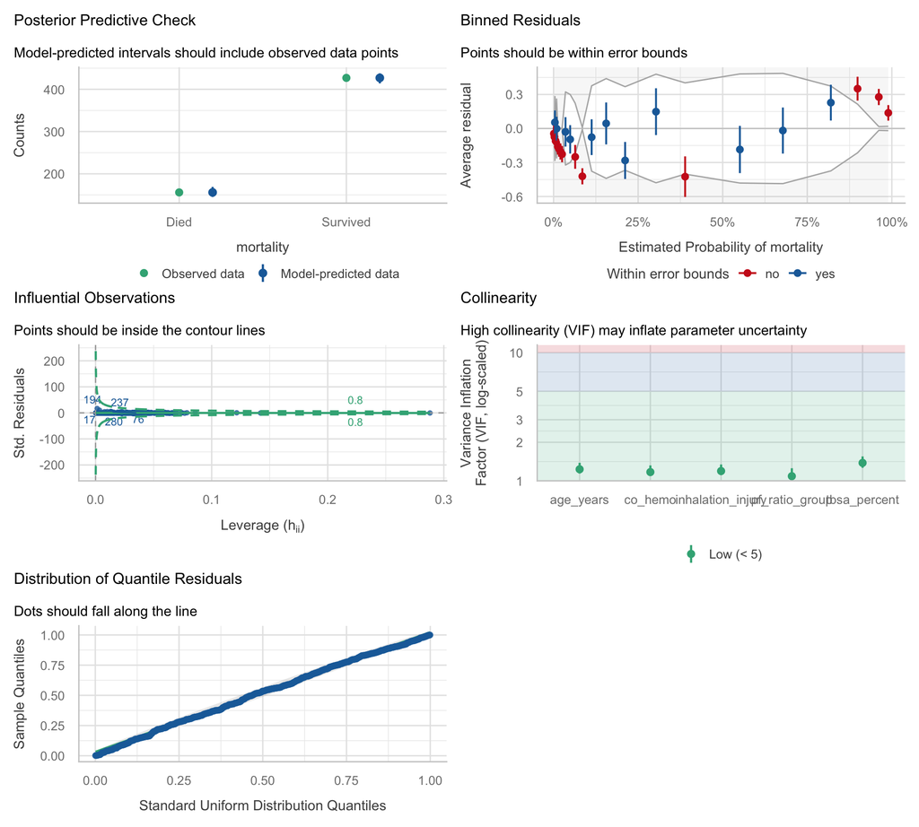

```r
check_model(mv_model)
```

Use the plots to answer the questions below.

**Question 4.3:** Read the collinearity panel. Which predictors show the highest VIF, and is it severe?

Ans 4.3:

**Answer:** All VIF values are low (roughly 1.1 to 1.4), with TBSA highest at about 1.4. Values below about 5 (some say 10) are not concerning, so collinearity is **not a problem** here.

**Question 4.4:** Read the binned-residuals panel. Ideally about 95% of the binned residuals fall inside the error bounds. What do you see, and what might it suggest about the model’s shape?

## A more suitable residual check

For logistic regression, the ordinary residuals are not expected to be normal, because each residual compares a 0/1 outcome with a fitted probability. In fact, if you call `check_normality(mv_model)` directly, the function itself tells you that GLM residuals are not expected to follow a normal distribution, and points you to **simulated quantile residuals** instead.

The idea: we simulate many plausible outcome datasets from the fitted model, then ask whether the observed data look like a typical simulation. If the model family is appropriate, the resulting quantile residuals should be uniformly distributed.

```r
simulated_res <- simulate_residuals(mv_model)
check_residuals(simulated_res)
```

```
## OK: Simulated residuals appear as uniformly distributed (p = 0.381).
```

**Question 4.6:** What does this test conclude for our model?

Ans 4.6:

**Answer:** The simulated residuals are consistent with a **uniform distribution** (p ≈ 0.4), so there is no evidence that the binomial model family is inappropriate for these data.

# PART 5: Functional forms and AIC

The “Shape” and “Into the model” checks ask whether each predictor enters the model in the right **functional form**. For a continuous predictor in a logistic model, the default form assumes the effect is **linear in the log-odds**: each one-unit increase adds the same amount to the log-odds, wherever on the scale it occurs.

How should you choose the form? In practice, the choice is usually guided by prior knowledge and by what the existing literature does (for example, burns severity scores such as ABSI treat age as a linear term). But if you have doubts, you can compare a small set of sensible candidate forms with AIC, as you did in the pre-work. Comparing every form you can imagine makes it easy to select a pattern that arose by chance, so keep the candidate set small and justified.

Below we compare three forms for age, using simple univariable models so all 676 patients can be used:

1. **Linear**: age enters as a single continuous term
2. **Decade groups**: age is cut into familiar decade bands
3. **Quadratic**: age enters together with an age-squared term

## Check the shape visually: empirical log-odds

First, let’s look at the data. The code below groups patients into decade bands and converts each band’s observed mortality proportion into log-odds. If age’s effect is linear in the log-odds, these points should rise along a roughly straight line.

```r
burns <- burns %>%
  mutate(age_decade = cut(age_years,
                          breaks = c(17, 29, 39, 49, 59, 69, 79, Inf),
                          labels = c("18-29", "30s", "40s", "50s", "60s", "70s", "80+"),
                          include.lowest = TRUE))

burns %>% tabyl(age_decade)
```

```
##  age_decade   n    percent
##       18-29  73 0.10798817
##         30s  93 0.13757396
##         40s 193 0.28550296
##         50s 186 0.27514793
##         60s  59 0.08727811
##         70s  50 0.07396450
##         80+  22 0.03254438
```

```r
age_shape_summary <- burns %>%
  group_by(age_decade) %>%
  summarise(
    age_mid = median(age_years),
    patients = n(),
    observed_probability = mean(mortality == "Died"),
    observed_log_odds = log(observed_probability / (1 - observed_probability)),
    .groups = "drop"
  )

age_shape_summary
```

```
## # A tibble: 7 × 5
##   age_decade age_mid patients observed_probability observed_log_odds
##   <fct>        <dbl>    <int>                <dbl>             <dbl>
## 1 18-29         25         73                0.192            -1.44
## 2 30s           36         93                0.161            -1.65
## 3 40s           44        193                0.181            -1.51
## 4 50s           54        186                0.285            -0.920
## 5 60s           64         59                0.373            -0.520
## 6 70s           75         50                0.42             -0.323
## 7 80+           82.5       22                0.591             0.368
```

**Question 5.1:** Looking at the `observed_log_odds` column, does the relationship with age look roughly linear?

Ans 5.1:

**Answer:** Roughly, yes. The observed log-odds rise fairly steadily from the 40s onward, with a small dip across the 30s and 40s. The overall pattern is close to a straight-line increase, so the linear-in-log-odds assumption looks reasonable for age.

## Fit the three candidate forms

Fit the three models yourself.

```r
# 1. Linear: mortality ~ age_years
age_linear_model <- glm(mortality ~ ______, family = binomial, data = burns)

# 2. Decade groups: mortality ~ age_decade
age_decade_model <- glm(mortality ~ ______, family = binomial, data = burns)

# 3. Quadratic: mortality ~ age_years + I(age_years^2)
age_quad_model <- glm(mortality ~ age_years + I(______), family = binomial, data = burns)
```

**Answer:**

```r
age_linear_model <- glm(mortality ~ age_years, family = binomial, data = burns)

age_decade_model <- glm(mortality ~ age_decade, family = binomial, data = burns)

age_quad_model <- glm(mortality ~ age_years + I(age_years^2), family = binomial, data = burns)
```

Now compare the three models with AIC.

```r
# Pass the three model objects to AIC()
AIC(______, ______, ______)
```

**Answer:**

```r
AIC(age_linear_model, age_decade_model, age_quad_model)
```

```
##                  df      AIC
## age_linear_model  2 742.8202
## age_decade_model  7 748.3094
## age_quad_model    3 742.9184
```

**Question 5.2:** Which functional form would you keep, and why? Comment on both the AIC values and the number of parameters.

Ans 5.2:

**Answer:** Keep the **linear** form. It has the lowest AIC (742.8) with only 2 parameters. The quadratic form is essentially tied (742.9, a difference well below 2), so its extra parameter buys no meaningful improvement and only makes the model harder to interpret. The decade groups fit worse (748.3 with 7 parameters) and also discard information by cutting a continuous variable. Prior knowledge points the same way: burns severity scores such as ABSI treat age as a simple linear term.

## See the three forms on two scales

The provided code below predicts the fitted values of each model across ages 18 to 90, on both the log-odds scale and the probability scale.

```r
age_grid <- tibble(age_years = 18:90) %>%
  mutate(age_decade = cut(age_years,
                          breaks = c(17, 29, 39, 49, 59, 69, 79, Inf),
                          labels = c("18-29", "30s", "40s", "50s", "60s", "70s", "80+"),
                          include.lowest = TRUE))

age_predictions <- age_grid %>%
  mutate(
    linear_log_odds = predict(age_linear_model, newdata = ., type = "link"),
    decade_log_odds = predict(age_decade_model, newdata = ., type = "link"),
    quad_log_odds   = predict(age_quad_model,   newdata = ., type = "link")
  ) %>%
  mutate(across(ends_with("log_odds"), ~ 1 / (1 + exp(-.x)),
                .names = "{str_replace(.col, 'log_odds', 'prob')}"))

age_predictions
```

```
## # A tibble: 73 × 8
##    age_years age_decade linear_log_odds decade_log_odds quad_log_odds
##        <int> <fct>                <dbl>           <dbl>         <dbl>
##  1        18 18-29                -2.15           -1.44         -1.70
##  2        19 18-29                -2.11           -1.44         -1.69
##  3        20 18-29                -2.08           -1.44         -1.69
##  4        21 18-29                -2.05           -1.44         -1.68
##  5        22 18-29                -2.01           -1.44         -1.68
##  6        23 18-29                -1.98           -1.44         -1.67
##  7        24 18-29                -1.95           -1.44         -1.67
##  8        25 18-29                -1.91           -1.44         -1.66
##  9        26 18-29                -1.88           -1.44         -1.65
## 10        27 18-29                -1.85           -1.44         -1.64
## # ℹ 63 more rows
## # ℹ 3 more variables: linear_prob <dbl>, decade_prob <dbl>, quad_prob <dbl>
```

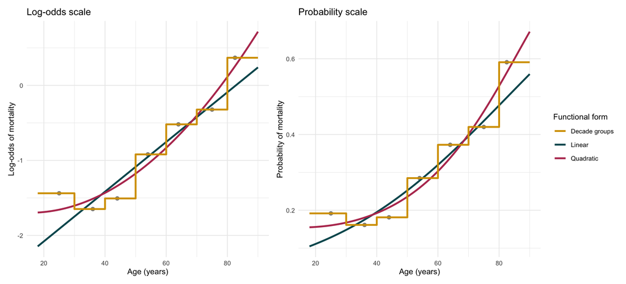

```r
form_colors <- c("Linear" = "#00565e", "Quadratic" = "#b83b5e", "Decade groups" = "#d69f00")

plot_log_odds <- ggplot(age_predictions, aes(x = age_years)) +
  geom_point(data = age_shape_summary,
             aes(x = age_mid, y = observed_log_odds),
             color = "grey45", size = 2, alpha = 0.8) +
  geom_line(aes(y = linear_log_odds, color = "Linear"), linewidth = 1.1) +
  geom_line(aes(y = quad_log_odds, color = "Quadratic"), linewidth = 1.1) +
  geom_step(aes(y = decade_log_odds, color = "Decade groups"), linewidth = 1.1) +
  scale_color_manual(values = form_colors) +
  labs(x = "Age (years)", y = "Log-odds of mortality",
       title = "Log-odds scale", color = "Functional form") +
  theme_minimal(base_size = 10)

plot_probability <- ggplot(age_predictions, aes(x = age_years)) +
  geom_point(data = age_shape_summary,
             aes(x = age_mid, y = observed_probability),
             color = "grey45", size = 2, alpha = 0.8) +
  geom_line(aes(y = linear_prob, color = "Linear"), linewidth = 1.1) +
  geom_line(aes(y = quad_prob, color = "Quadratic"), linewidth = 1.1) +
  geom_step(aes(y = decade_prob, color = "Decade groups"), linewidth = 1.1) +
  scale_color_manual(values = form_colors) +
  labs(x = "Age (years)", y = "Probability of mortality",
       title = "Probability scale", color = "Functional form") +
  theme_minimal(base_size = 10)

plot_log_odds + plot_probability + plot_layout(guides = "collect")
```

The grey points are the observed decade-band values from the previous section.

**Question 5.3:** The linear model is a straight line on the log-odds scale but a curve on the probability scale. Why?

Ans 5.3:

**Answer:** The model is linear on the log-odds (link) scale **by construction**: the linear predictor is a straight line by definition. Converting log-odds to probabilities uses the nonlinear inverse-logit (sigmoid) transformation, which bends the straight line into an S-shaped curve.

**Question 5.4:** Why is `geom_step()` the right geom for the decade-group model?

Ans 5.4:

**Answer:** The decade model assigns **one constant fitted value to everyone within a band**, so its predictions stay flat within each band and jump only at the band boundaries. That staircase shape is exactly what `geom_step()` draws; a smooth line would wrongly suggest the estimate changes gradually within a band.

# PART 6: Report the multivariable results

**Final reporting task:** Complete this results paragraph using the multivariable model from Part 3.

Ans:

> In a multivariable logistic regression model adjusting for all other predictors, each additional year of age was associated with ______% higher odds of mortality (OR ______, 95% CI 1.046 to 1.091), and each additional percentage point of TBSA burned was associated with ______% higher odds (OR ______, 95% CI 1.083 to 1.120). Compared with Normal inhalation status, the Upper group had OR ______ (95% CI 1.635 to 9.945) and the Lower group had OR ______ (95% CI 1.091 to 5.163). Compared with PF ratio >300, the <100 group had OR ______ (95% CI 0.645 to 3.736), which ______ (was / was not) statistically significant. Each additional percentage point of carboxyhemoglobin had OR ______ (95% CI 0.995 to 1.183).

**Answer:** In a multivariable logistic regression model adjusting for all other predictors, each additional year of age was associated with **6.8**% higher odds of mortality (OR **1.068**, 95% CI 1.046 to 1.091), and each additional percentage point of TBSA burned was associated with **10.0**% higher odds (OR **1.100**, 95% CI 1.083 to 1.120). Compared with Normal inhalation status, the Upper group had OR **3.993** (95% CI 1.635 to 9.945) and the Lower group had OR **2.369** (95% CI 1.091 to 5.163). Compared with PF ratio >300, the <100 group had OR **1.547** (95% CI 0.645 to 3.736), which **was not** statistically significant. Each additional percentage point of carboxyhemoglobin had OR **1.093** (95% CI 0.995 to 1.183).

# CHALLENGE: A publication-style table with an LLM

Regression tables in papers often combine **raw numbers** (event counts and percentages) with **adjusted or unadjusted odds ratios** and a **forest plot**, all in one display, like the example below.

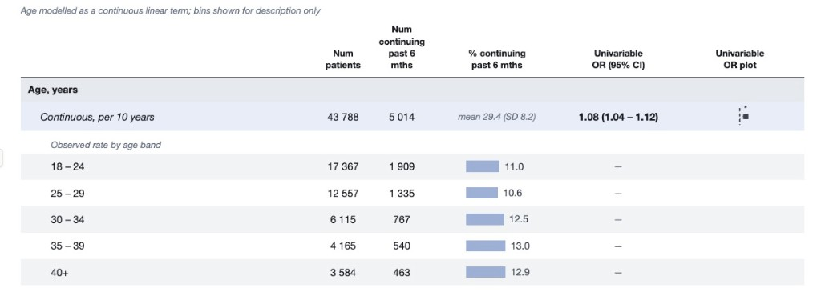

Example of a combined regression table with raw proportions and a forest plot.

Writing this kind of formatting code by hand is slow, and it is a reasonable place to get help from an LLM. Your challenge:

1. Ask an LLM to write R code that produces a table like the one above for the **six univariable models** of this workshop, with one row per comparison, the raw deaths/N (%) for each category, the OR (95% CI), the p-value, and a forest plot.
2. Check every number against the model output you produced in Part 2. Never trust formatted values you cannot reproduce.

You can look at a worked example from a previous workshop in the course GitHub repository: table4_replication_gpt5_a7k2 (with a second attempt in llin_table4_grok_w8r3).

One limitation of that example: all of its predictors are categorical, so an LLM imitating it may not know what to do with **continuous** predictors like age and TBSA, which have no natural categories for the raw n/N (%) columns. The usual solution, shown in the example image above, is:

> Model the predictor as continuous (one OR per unit increase), but still **cut it into categories for display**, so readers can see the raw event proportions.

The workshop folder contains a from-scratch example that uses exactly this idea on the `birthwt` dataset from the `MASS` package (outcome: low birth weight; predictors: continuous age and weight, binary smoking, polytomous race, and previous premature labours recoded as 0 / 1 / 2+). Study it and adapt its ideas:

`scripts/birthwt_regression_table_example.R`

## Challenge facilitator notes

Running `scripts/birthwt_regression_table_example.R` produces `scripts/birthwt_regression_table.png`, a table in the style of the example image. Points to check when students use an LLM for this task:

- The raw n/N (%) values should match simple `count()`/`tabyl()` summaries, not model output.
- Continuous predictors should contribute **one** odds ratio per unit increase, even though categories are shown for the raw proportions.
- Reference categories should display “Reference” (or OR = 1) rather than an estimated OR.
- All ORs and CIs should match `tidy(model, conf.int = TRUE, exponentiate = TRUE)` output.

# Reference

Kim Y, Kym D, Hur J, Yoon J, Yim H, Cho YS, et al. (2017). Does inhalation injury predict mortality in burns patients or require redefinition? *PLOS ONE*, 12(9), e0185195. https://doi.org/10.1371/journal.pone.0185195